# Cartografia Temática e Leitura Integrada da Paisagem

Análise da Paisagem · Aula 4.3

Prof. Dr. Luiz Diego Vidal Santos

## Visão Geral da Aula

### Tópicos

- 1 Cartografia temática: o que é e para que serve
- 2 Tipos de mapas temáticos para análise da paisagem
- 3 Leitura de mapas: relevo, drenagem e geomorfologia
- 4 Leitura de mapas: uso e cobertura da terra
- 5 Leitura integrada: cruzar informações espaciais
- 6 Bases públicas de dados espaciais

**Objetivo da Aula**

Desenvolver a capacidade de **leitura e interpretação** de mapas temáticos (relevo, drenagem, uso/cobertura, redes) como ferramenta para a **análise integrada da paisagem** e a delimitação de unidades territoriais.

# CARTOGRAFIA TEMÁTICA

## O que é cartografia temática?

### Definição

A **cartografia temática** representa informações específicas sobre um tema geográfico em base cartográfica:

- **Mapa de relevo** - altimetria, declividade, hipsometria
- **Mapa geológico/geomorfológico** - tipos de rocha, formas de relevo
- **Mapa de solos** - classes pedológicas
- **Mapa de uso e cobertura** - vegetação, agricultura, urbano
- **Mapa de drenagem** - rede hidrográfica, bacias
- **Mapa de vulnerabilidade** - combinação de temas

### Diferença da cartografia de referência

A cartografia de **referência** (topográfica) mostra elementos básicos (estradas, cidades, relevo). A **temática** destaca um aspecto específico para análise.

**Para que serve na análise da paisagem?**

1. **Identificar padrões** - distribuição espacial de coberturas, formas, usos
2. **Delimitar unidades** - áreas homogêneas ou com dinâmica similar
3. **Cruzar informações** - sobrepor camadas para identificar relações
4. **Comunicar** - síntese visual para diagnóstico e planejamento
5. **Monitorar** - comparar mapas de datas diferentes (mudanças)

### Princípio fundamental

> *“O mapa temático não é fim em si - é ferramenta de leitura. A análise está na interpretação, não na cartografia.”*

Mapas bonitos com interpretação superficial → mau trabalho. Mapas simples com interpretação fundamentada → bom trabalho.

# TIPOS DE MAPAS PARA ANÁLISE DA PAISAGEM

## Mapa hipsométrico e de declividade

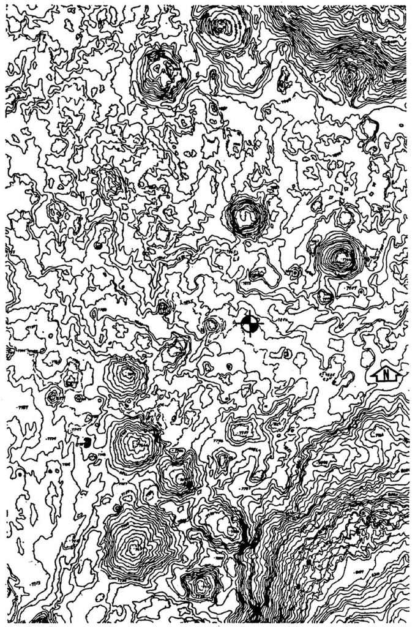

### Mapa hipsométrico

- Representa a **altitude** por classes de cor (faixas altitudinais)
- Permite identificar: planaltos, vales, escarpas, depressões
- Base: Modelo Digital de Elevação (MDE) - SRTM 30 m, ALOS 12,5 m

### Mapa de declividade

- Representa o **gradiente de inclinação** do terreno
- Classes comuns: 0-3% (plano), 3-8% (suave-ondulado), 8-20% (ondulado), 20-45% (forte-ondulado), >45% (montanhoso/escarpado)
- Fundamental para: aptidão agrícola, risco de erosão, restrição à ocupação

**O que ler nesses mapas (para paisagem)?**

1. **Posição topográfica** - topos, vertentes, fundos de vale → unidades de paisagem diferentes
2. **Dissecação** - relevo muito dissecado = paisagem fragmentada naturalmente
3. **Declividade e uso** - áreas íngremes com pastagem = risco de erosão
4. **Contraste** - planícies extensas vs. áreas acidentadas → diversidade paisagística
5. **Controle estrutural** - alinhamentos de serra, vales encaixados → geologia

### Fontes públicas

- **TOPODATA** (INPE) - MDE 30 m do Brasil
- **SRTM** (NASA) - MDE 30 m global
- **ALOS PALSAR** (JAXA) - MDE 12,5 m
- **MapBiomas Alerta** - integra com relevo

## Mapa de drenagem e bacias hidrográficas

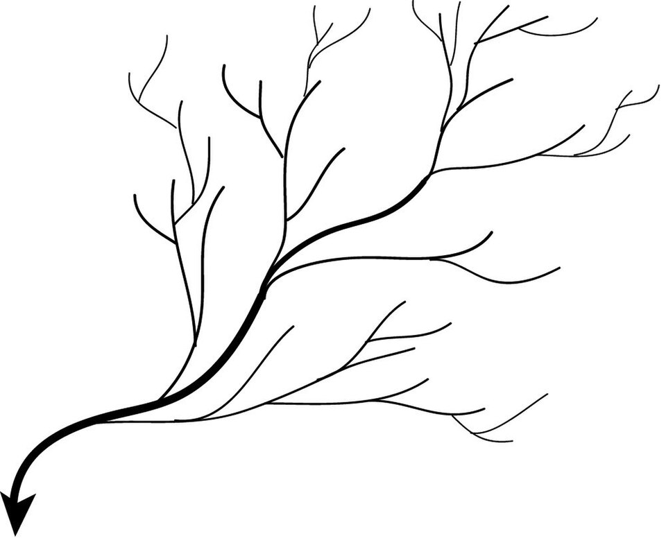

Padrão de drenagem dendrítico

### Rede de drenagem

- Representação dos cursos d’água (rios, córregos, nascentes)
- Permite identificar: padrão de drenagem, hierarquia (Strahler), densidade
- Relação direta com relevo, geologia e clima

### Padrões de drenagem

| Padrão | Indicação |
| --- | --- |
| **Dendrítico** | Rochas homogêneas, resistência uniforme |
| **Treliça** | Controle estrutural, rochas com diferentes resistências |
| **Paralelo** | Declividade uniforme, controle estrutural |
| **Radial** | Estrutura dômica ou vulcânica |
| **Anelar** | Domo ou estrutura circular |

**O que ler (para paisagem)?**

1. **Densidade de drenagem** - alta densidade = solos impermeáveis/rasos → escoamento superficial dominante
2. **Hierarquia** - rios de 1ª ordem (nascentes) → gestão de APPs
3. **Padrão** - indica controle geológico/estrutural
4. **Confluências** - pontos de acumulação de fluxo → vulnerabilidade a inundação
5. **Intermitência** - rios intermitentes (semiárido) → padrão sazonal da paisagem

### Bacia hidrográfica como unidade de análise

A **bacia hidrográfica** é frequentemente usada como recorte territorial para análise da paisagem:

- Limites naturais (divisores de água)
- Integra fluxos hídricos e sedimentares
- Unidade legal de gestão (Política de Recursos Hídricos)

## Mapa de uso e cobertura da terra

[figure not shown]

### O mapa mais usado na análise da paisagem

Classifica cada porção do território por sua **cobertura** (vegetação, água, solo exposto) e **uso** (agrícola, urbano, industrial):

| Classe | Tipo |
| --- | --- |
| Floresta / vegetação nativa densa | Cobertura natural |
| Vegetação secundária / capoeira | Cobertura em regeneração |
| Pastagem | Uso agropecuário |
| Agricultura anual / perene | Uso agrícola |
| Área urbana | Uso antrópico |
| Solo exposto | Degradação / preparo |
| Corpo d’água | Natural / artificial |
| Mineração | Uso extrativo |

**Fontes públicas**

| Fonte | Resolução | Cobertura |
| --- | --- | --- |
| **MapBiomas** | 30 m | Brasil, 1985-2023 |
| **PRODES** (INPE) | 30 m | Amazônia, Cerrado |
| **TerraClass** | 30 m | Amazônia |
| **ESA WorldCover** | 10 m | Global |
| **Dynamic World** (Google) | 10 m | Global, anual |
| **IBGE** | Variável | Censos agropecuários |

### Importância

O mapa de uso/cobertura é a **base** para:

- Identificar matriz, manchas e corredores
- Calcular métricas de fragmentação
- Detectar mudanças temporais
- Elaborar o dossiê da paisagem

# LEITURA INTEGRADA

## Cruzar camadas: o poder da sobreposição

### Princípio

A leitura integrada consiste em **sobrepor** mapas temáticos para identificar **relações** que não são visíveis em um mapa isolado:

| Sobreposição | O que revela |
| --- | --- |
| Declividade + uso | Pastagem em área íngreme → risco de erosão |
| Drenagem + cobertura | Nascentes sem mata ciliar → APP violada |
| Relevo + fragmentação | Fragmentos restritos a topos → relictos |
| Uso + solo | Agricultura em solo raso → baixa aptidão |
| Estradas + habitat | Rodovias cortando fragmentos → barreira |

**Métodos de cruzamento**

1. **Visual** - sobreposição em GIS, leitura comparativa
2. **Álgebra de mapas** - combinação raster (ex.: mapa de aptidão = solo + declividade + clima)
3. **Carta de síntese** - produto que integra múltiplas variáveis em unidades interpretadas (carta geoambiental)
4. **Perfil geoambiental** - corte transversal mostrando relações vertical-horizontais

### Atenção

Cruzar mapas sem **interpretação** produz apenas colagens. O geógrafo/analista precisa **interpretar** as relações - a tecnologia não substitui o raciocínio.

> *“SIG é ferramenta. A análise é do geógrafo.”*

# BASES PÚBLICAS DE DADOS ESPACIAIS

## Principais bases para o Brasil

| Base | Dado | URL |
| --- | --- | --- |
| **MapBiomas** | Uso/cobertura 1985-2023, 30 m | mapbiomas.org |
| **TOPODATA** | MDE, declividade, 30 m | topodata.inpe.br |
| **IBGE** | Bases cartográficas, censos, malha | ibge.gov.br/geociencias |
| **ANA** | Bacias, hidrografia, outorgas | snirh.gov.br |
| **CAR** (SICAR) | Cadastro Ambiental Rural | car.gov.br |
| **ICMBio** | Unidades de conservação | icmbio.gov.br |
| **CPRM** | Geologia, hidrogeologia | geosgb.cprm.gov.br |
| **EMBRAPA** | Solos, aptidão agrícola | embrapa.br/solos |

**Plataformas em nuvem**

| Plataforma | Capacidade |
| --- | --- |
| **Google Earth Engine** | Processamento de imagens em escala planetária |
| **MapBiomas Plataforma** | Visualização interativa de séries temporais |
| **INPE TerraBrasilis** | Monitoramento de desmatamento |
| **Copernicus Browser** | Imagens Sentinel gratuitas |
| **Planet NICFI** | Imagens de alta resolução (tropical) |

### Dica operacional

Para o **dossiê da disciplina**, as bases mínimas são:

1. MDE (relevo/declividade)
2. MapBiomas (uso/cobertura)
3. Hidrografia (ANA ou derivada do MDE)
4. Limites administrativos (IBGE)

## Atividade prática: leitura cartográfica

### Proposta (em duplas, 30 min)

Utilizando projeção/tela com acesso ao **MapBiomas** e ao **Google Earth**:

1. **Selecione** o município de Feira de Santana (ou entorno definido pelo professor)
2. **Identifique** no mapa de uso/cobertura (2023):
   - A matriz dominante
   - Pelo menos 5 manchas de vegetação nativa
   - Corredores (matas ciliares visíveis?)
3. **Compare** com o mapa de relevo (TOPODATA):
   - Onde a vegetação nativa se concentra? (topos, encostas, fundos de vale?)
   - A declividade influencia a distribuição do uso?
4. **Elabore** um parágrafo de síntese descritiva (texto + sketch)

### Socialização (15 min)

**Objetivo**

- Praticar a **leitura cartográfica** orientada à análise da paisagem
- Conectar **relevo** e **uso** numa mesma interpretação
- Iniciar a **caracterização da área de estudo** do dossiê
- Familiarizar-se com **bases públicas**

> Este exercício será aprofundado na **Aula 11** com a delimitação formal da área de estudo.

**O que vimos hoje**

1. **Cartografia temática** - ferramenta para representar e interpretar temas geográficos
2. **Tipos de mapas** - hipsométrico, declividade, drenagem, uso/cobertura, geomorfológico
3. **Leitura de relevo** - posição topográfica, dissecação, declividade e aptidão
4. **Leitura de drenagem** - padrões, hierarquia, densidade, bacia como unidade
5. **Leitura de uso/cobertura** - base para análise de matriz-mancha-corredor
6. **Leitura integrada** - cruzamento de camadas para identificar relações
7. **Bases públicas** - MapBiomas, TOPODATA, ANA, IBGE, GEE, SICAR

Obrigado!

Luiz Diego Vidal Santos

Universidade Estadual de Feira de Santana (UEFS)